# San Francisco bike share network

Thuan Khang Dinh

2024-12-30

**For Github version follow [link](https://github.com/thuankhang/casestudy-sf-bikeshare)**

# Introduction

This report analyzes the San Francisco bike share network using data from two datasets:

- July 7–13, 2014
- July 6–12, 2015

The goals are to evaluate the evolution of the network between 2014 and 2015 and identify critical stations or routes.

# Data Loading

## Loading the Data

```r
stations = read.csv("https://raw.githubusercontent.com/thuankhang/casestudy-sf-bikeshare/refs/heads/main/data/SF-bikeshare-station-info.csv")
trips_2014 = read.csv("https://raw.githubusercontent.com/thuankhang/casestudy-sf-bikeshare/refs/heads/main/data/SF-bikeshare-1-week-2014-07.csv")
trips_2015 = read.csv("https://raw.githubusercontent.com/thuankhang/casestudy-sf-bikeshare/refs/heads/main/data/SF-bikeshare-1-week-2015-07.csv")
```

# Data Wrangling

## Understand the dataset

We have 3 datasets:

- `stations`:

```r
str(stations)
```

```
## 'data.frame':    70 obs. of  7 variables:
##  $ id               : int  2 3 4 5 6 7 8 9 10 11 ...
##  $ name             : chr  "San Jose Diridon Caltrain Station" "San Jose Civic Center" "Santa Clara at Almaden" "Adobe on Almaden" ...
##  $ lat              : num  37.3 37.3 37.3 37.3 37.3 ...
##  $ long             : num  -122 -122 -122 -122 -122 ...
##  $ dock_count       : int  27 15 11 19 15 15 15 15 15 19 ...
##  $ city             : chr  "San Jose" "San Jose" "San Jose" "San Jose" ...
##  $ installation_date: chr  "8/6/2013" "8/5/2013" "8/6/2013" "8/5/2013" ...
```

- `trips_2014`:

```r
str(trips_2014)
```

```
## 'data.frame':    6911 obs. of  7 variables:
##  $ start_date_yyyymmdd: chr  "2014-07-13" "2014-07-13" "2014-07-13" "2014-07-13" ...
##  $ start_station_name : chr  "Powell at Post (Union Square)" "Market at 4th" "Market at 4th" "Grant Avenue at Columbus Avenue" ...
##  $ start_station_id   : int  71 76 76 73 50 2 61 75 28 71 ...
##  $ end_date_yyyymmdd  : chr  "2014-07-13" "2014-07-13" "2014-07-13" "2014-07-13" ...
##  $ end_station_name   : chr  "Embarcadero at Bryant" "Market at 10th" "Market at 10th" "Powell at Post (Union Square)" ...
##  $ end_station_id     : int  54 67 67 71 63 4 54 57 32 39 ...
##  $ duration           : int  667 401 401 470 421 221 233 455 559 1386 ...
```

- `trips_2015`:

```r
str(trips_2015)
```

```
## 'data.frame':    7381 obs. of  7 variables:
##  $ start_date_yyyymmdd: chr  "2015-07-12" "2015-07-12" "2015-07-12" "2015-07-12" ...
##  $ start_station_name : chr  "Howard at 2nd" "Temporary Transbay Terminal (Howard at Beale)" "San Jose City Hall" "Clay at Battery" ...
##  $ start_station_id   : int  63 55 10 41 77 42 16 16 76 50 ...
##  $ end_date_yyyymmdd  : chr  "2015-07-12" "2015-07-12" "2015-07-12" "2015-07-12" ...
##  $ end_station_name   : chr  "Market at Sansome" "Powell Street BART" "SJSU - San Salvador at 9th" "Washington at Kearny" ...
##  $ end_station_id     : int  77 39 16 46 73 49 10 16 69 56 ...
##  $ duration           : int  121 444 444 166 624 363 570 82 402 5868 ...
```

## Summary:

Let’s get the summary of `trips_2014` and `trips_2015`:

```r
summary(trips_2014)
```

```
##  start_date_yyyymmdd start_station_name start_station_id end_date_yyyymmdd
##  Length:6911         Length:6911        Min.   : 2.00    Length:6911
##  Class :character    Class :character   1st Qu.:50.00    Class :character
##  Mode  :character    Mode  :character   Median :62.00    Mode  :character
##                                         Mean   :57.63
##                                         3rd Qu.:70.00
##                                         Max.   :84.00
##  end_station_name   end_station_id     duration
##  Length:6911        Min.   : 2.00   Min.   :    61
##  Class :character   1st Qu.:49.00   1st Qu.:   348
##  Mode  :character   Median :61.00   Median :   520
##                     Mean   :57.23   Mean   :  1158
##                     3rd Qu.:70.00   3rd Qu.:   753
##                     Max.   :84.00   Max.   :715339
```

```r
summary(trips_2015)
```

```
##  start_date_yyyymmdd start_station_name start_station_id end_date_yyyymmdd
##  Length:7381         Length:7381        Min.   : 2.00    Length:7381
##  Class :character    Class :character   1st Qu.:50.00    Class :character
##  Mode  :character    Mode  :character   Median :61.00    Mode  :character
##                                         Mean   :57.65
##                                         3rd Qu.:70.00
##                                         Max.   :84.00
##  end_station_name   end_station_id     duration
##  Length:7381        Min.   : 2.00   Min.   :     61
##  Class :character   1st Qu.:50.00   1st Qu.:    356
##  Mode  :character   Median :61.00   Median :    531
##                     Mean   :57.69   Mean   :   1198
##                     3rd Qu.:70.00   3rd Qu.:    768
##                     Max.   :84.00   Max.   :1133540
```

## NA observations

```r
sum(is.na(stations))
```

```
## [1] 0
```

```r
sum(is.na(trips_2014))
```

```
## [1] 0
```

```r
sum(is.na(trips_2015))
```

```
## [1] 0
```

There is no missing(NA) values in any of the datasets.

## Preprocessing

Standardize the datasets for consistent analysis.

### Data Conversion and Cleanup

Add columns for start city, end city, and trip between cities.

```r
trips_2014$start_city = stations$city[match(trips_2014$start_station_id, stations$id)]
trips_2014$end_city = stations$city[match(trips_2014$end_station_id, stations$id)]
trips_2014$trip_between_cities = paste(trips_2014$start_city, "->", trips_2014$end_city)


trips_2015$start_city = stations$city[match(trips_2015$start_station_id, stations$id)]
trips_2015$end_city = stations$city[match(trips_2015$end_station_id, stations$id)]
trips_2015$trip_between_cities = paste(trips_2015$start_city, "->", trips_2015$end_city)
```

Add latitude and longitude information for each station.

```r
trips_2014$start_station_lat = stations$lat[match(trips_2014$start_station_id, stations$id)]
trips_2014$start_station_long = stations$long[match(trips_2014$start_station_id, stations$id)]
trips_2014$end_station_lat = stations$lat[match(trips_2014$end_station_id, stations$id)]
trips_2014$end_station_long = stations$long[match(trips_2014$end_station_id, stations$id)]


trips_2015$start_station_lat = stations$lat[match(trips_2015$start_station_id, stations$id)]
trips_2015$start_station_long = stations$long[match(trips_2015$start_station_id, stations$id)]
trips_2015$end_station_lat = stations$lat[match(trips_2015$end_station_id, stations$id)]
trips_2015$end_station_long = stations$long[match(trips_2015$end_station_id, stations$id)]
```

# Analyze

## a. Station Statistics

### Overall:

We will find number of unique stations in July each year.

```r
stations_2014 = unique(c(trips_2014$start_station_id, trips_2014$end_station_id))
stations_2015 = unique(c(trips_2015$start_station_id, trips_2015$end_station_id))
```

- Number of stations in July 2014: 69.
- Number of stations in July 2015: 70.

There are more stations on July 2015, so we will find new stations and removed stations (if have) over the year:

```r
new_stations = setdiff(stations_2015, stations_2014)
removed_stations = setdiff(stations_2014, stations_2015)
```

- New stations in July 2015: Redwood City Medical Center
- Removed stations in July 2015:

### By City:

First, we will need to find out how many cities are there, and what are those for later using.

```r
city_2014 = unique(stations$city[stations$id %in% unique(union(trips_2014$start_station_id, trips_2014$end_station_id))])
city_2015 = unique(stations$city[stations$id %in% unique(union(trips_2015$start_station_id, trips_2015$end_station_id))])
```

- In July 2014: Cities: San Jose, Redwood City, Mountain View, Palo Alto, San Francisco.
- In July 2015: Cities: San Jose, Redwood City, Mountain View, Palo Alto, San Francisco.

There are in total 5 cities in dataset of July 2014 and 5 cities in dataset of July 2015

- In July 2014:

```r
stations_2014_count = table(stations$city[stations$id %in% stations_2014])
stations_2014_count
```

```
##
## Mountain View     Palo Alto  Redwood City San Francisco      San Jose
##             7             5             6            35            16
```

```r
write.csv(stations_2014_count, "num_stations_city_2014.csv")
```

- In July 2015:

```r
stations_2015_count = table(stations$city[stations$id %in% stations_2015])
stations_2015_count
```

```
##
## Mountain View     Palo Alto  Redwood City San Francisco      San Jose
##             7             5             7            35            16
```

**Insights**

```
- As we found before, there are one more stations, and new station Redwood City Medical Center is in the Redwood City.
- Number of stations on each city still remains, except for Redwood City.
- San Francisco has the most number of stations, while Palo Alto has the least. We can make a prediction that the connectivity and volume in San Francisco will outweighted the others.
```

### Plotting

#### Pie chart number of stations each city over 2 years.

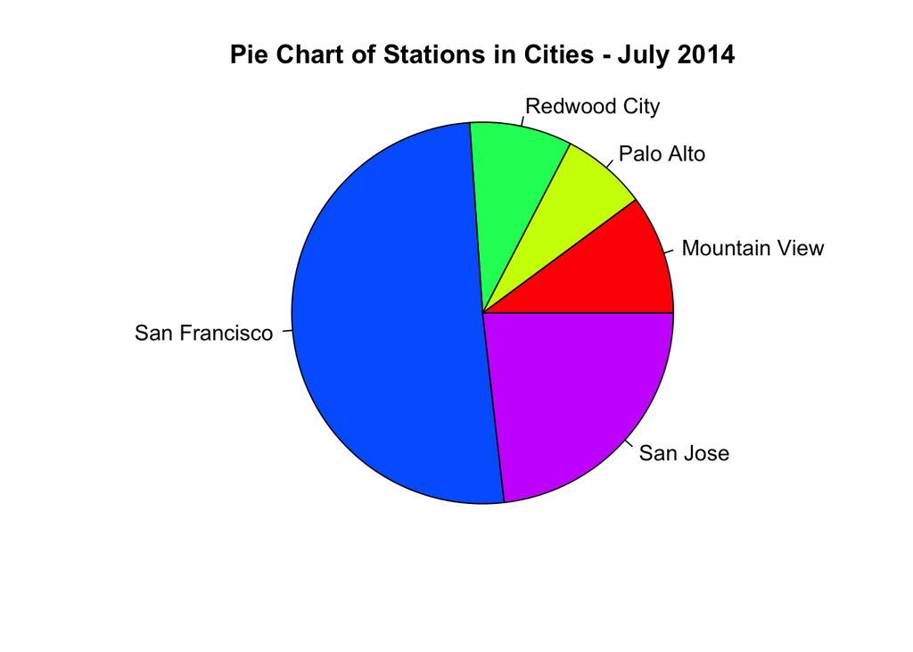

```r
pie(stations_2014_count,
    main = "Pie Chart of Stations in Cities - July 2014",
    col = rainbow(length(stations_2014_count)),
    radius = 1)
```

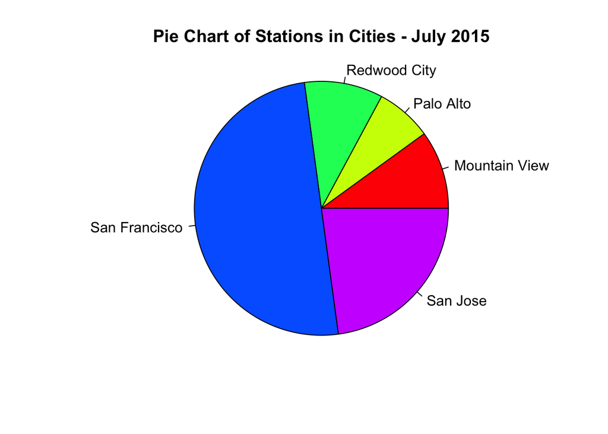

```r
pie(stations_2015_count,
    main = "Pie Chart of Stations in Cities - July 2015",
    col = rainbow(length(stations_2015_count)),
    radius = 1)
```

#### Grouped Bar Chart for comparing number of stations each city.

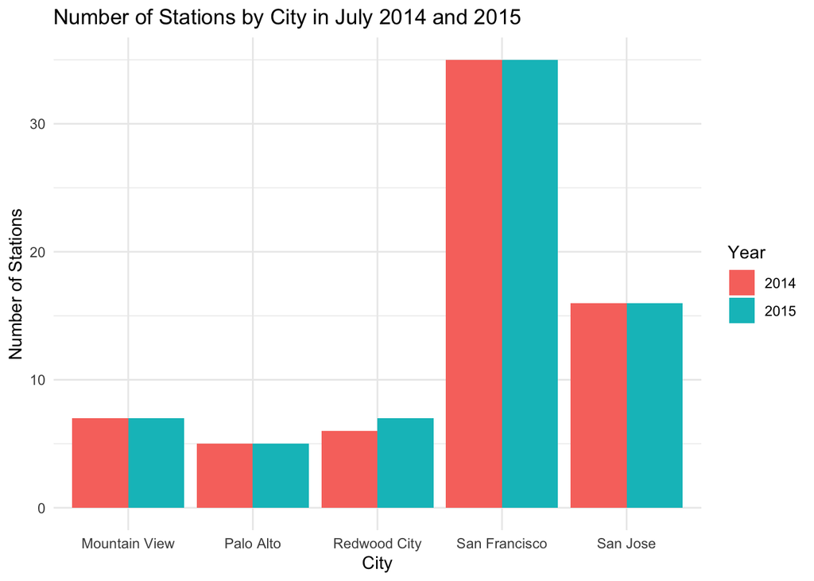

```r
stations_count = data.frame(
  City = rep(names(stations_2014_count), 2),
  Year = rep(c(2014, 2015), each = length(stations_2014_count)),
  Count = c(as.vector(stations_2014_count), as.vector(stations_2015_count))
)


ggplot(stations_count, aes(x = City, y = Count, fill = factor(Year))) +
  geom_bar(stat = "identity", position = "dodge") +
  theme(axis.text.x = element_text(angle = 45, hjust = 1)) +
  labs(x = "City", y = "Number of Stations", fill = "Year") +
  ggtitle("Number of Stations by City in July 2014 and 2015") +
  theme_minimal()
```

#### Graph for showing stations in map

Since the different between datasets in 2014 and 2015 is not huge enough, I will plot only graph for the year 2014.

First, get dataframe of station start, end and vol.

```r
stations_graphing_2014 = as.data.frame(table(trips_2014$start_station_id, trips_2014$end_station_id))
colnames(stations_graphing_2014) = c("Start", "End", "Vol")
```

Then, make graph using `graph_from_data_frame`

```r
graph_2014 = graph_from_data_frame(stations_graphing_2014)


long_2014 = c()
lat_2014 = c()
for (station_id in V(graph_2014)$name) {
  station_coords = stations[stations$id == station_id,]
  if (nrow(station_coords) > 0) {
    long_2014 = c(long_2014, station_coords$long)
    lat_2014 = c(lat_2014, station_coords$lat)
  } else {
    long_2014 = c(long_2014, NA)
    lat_2014 = c(lat_2014, NA)
  }
}

V(graph_2014)$x = long_2014
V(graph_2014)$y = lat_2014
V(graph_2014)$size = degree(graph_2014, mode = "out")*0.1
```

And plotting:

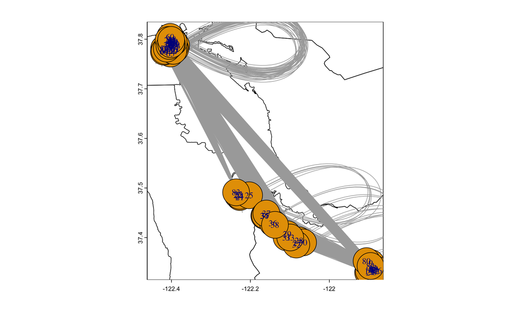

```r
USA <- geodata::gadm(country='USA', level=2, path = ".")

cities_map <- USA[USA$NAME_1 %in% "California",]

plot(cities_map,
     xlim = c(-122.45, -121.875),
     ylim = c(37.325, 37.825))

plot(graph_2014, add = TRUE, rescale = FALSE,
     edge.arrow.size = 0.01, edge.arrow.width = 0.75)
```

It is too difficult to see, so my first plan is I will delve into each city. But I cannot plot other city (I don’t know why) so I will plot only San Francisco.

The code are the same so I will skip explaining them.

##### San Francisco

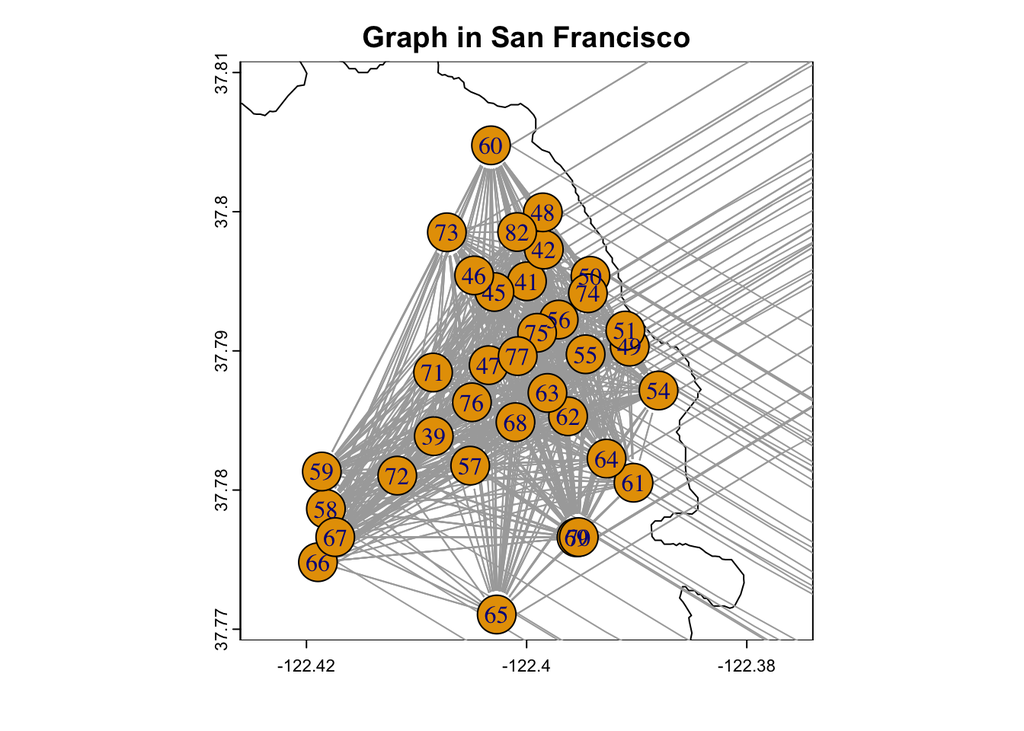

```r
stations_graphing_2014 = as.data.frame(table(trips_2014$start_station_id[trips_2014$start_city == "San Francisco" & trips_2014$end_city == "San Francisco"], trips_2014$end_station_id[trips_2014$start_city == "San Francisco" & trips_2014$end_city == "San Francisco"]))
colnames(stations_graphing_2014) = c("Start", "End", "Vol")

graph_2014 = graph_from_data_frame(stations_graphing_2014)


long_2014 = c()
lat_2014 = c()
for (station_id in V(graph_2014)$name) {
  station_coords = stations[stations$id == station_id,]
  if (nrow(station_coords) > 0) {
    long_2014 = c(long_2014, station_coords$long)
    lat_2014 = c(lat_2014, station_coords$lat)
  } else {
    long_2014 = c(long_2014, NA)
    lat_2014 = c(lat_2014, NA)
  }
}

V(graph_2014)$x = long_2014
V(graph_2014)$y = lat_2014
V(graph_2014)$size = degree(graph_2014, mode = "out")*0.01

USA <- geodata::gadm(country='USA', level=2, path = ".")
map <- USA[USA$NAME_2 == "San Francisco",]

plot(map,
     xlim = c(-122.425, -122.375),
     ylim = c(37.77, 37.81),
     main = "Graph in San Francisco")

plot(graph_2014, add = TRUE, rescale = FALSE,
     edge.arrow.size = 0.01, edge.arrow.width = 0.75)
```

## b. Trip Volumes

### Overall:

#### Total trips:

- Total trips in July 2014: 6911
- Total trips in July 2015: 7381

#### Total trips duration:

- Total trips duration in July 2014: 8003277 seconds, which is around 2223.13 hours.
- Total trips duration in July 2015: 8846153 seconds, which is 2457.26 hours.

#### Average trips duration:

- Average trip duration in July 2014: 1158.05 seconds.
- Average trip duration in July 2015: 1198.5 seconds.

**Insights**

```
- Total Trips: Increased from 6,911 in 2014 to 7,381 in 2015, reflecting greater bike-share usage.
- Total Trip Durations: Grew from 2,223.13 hours in 2014 to 2,457.26 hours in 2015, suggesting longer or more frequent trips.
- Average Trip Duration: Increased slightly from 1,158.05 seconds in 2014 to 1,198.5 seconds in 2015, indicating a trend toward longer rides.
```

### By city:

#### In July 2014:

```r
table_trips_2014 = as.data.frame(table(trips_2014$trip_between_cities))
colnames(table_trips_2014) = c("trip_between_cities_2014", "num_trips")
duration_2014 = c()
for (i in table_trips_2014$trip_between_cities_2014) {
  duration_2014 = c(duration_2014, sum(trips_2014$duration[trips_2014$trip_between_cities %in% i]))
}
table_trips_2014$duration = duration_2014
table_trips_2014$avg_duration = round(table_trips_2014$duration / table_trips_2014$num_trips, 2)
table_trips_2014
```

```
##         trip_between_cities_2014 num_trips duration avg_duration
## 1 Mountain View -> Mountain View       260   518743      1995.17
## 2     Mountain View -> Palo Alto         6    11596      1932.67
## 3     Palo Alto -> Mountain View         6     8959      1493.17
## 4         Palo Alto -> Palo Alto        86   144850      1684.30
## 5      Redwood City -> Palo Alto         2     6829      3414.50
## 6   Redwood City -> Redwood City        27    15796       585.04
## 7 San Francisco -> San Francisco      6071  5867541       966.49
## 8           San Jose -> San Jose       453  1428963      3154.44
```

```r
table_trips_2014$year = rep(2014, dim(table_trips_2014)[1])
table_trips_2014
```

```
##         trip_between_cities_2014 num_trips duration avg_duration year
## 1 Mountain View -> Mountain View       260   518743      1995.17 2014
## 2     Mountain View -> Palo Alto         6    11596      1932.67 2014
## 3     Palo Alto -> Mountain View         6     8959      1493.17 2014
## 4         Palo Alto -> Palo Alto        86   144850      1684.30 2014
## 5      Redwood City -> Palo Alto         2     6829      3414.50 2014
## 6   Redwood City -> Redwood City        27    15796       585.04 2014
## 7 San Francisco -> San Francisco      6071  5867541       966.49 2014
## 8           San Jose -> San Jose       453  1428963      3154.44 2014
```

#### In July 2015:

```r
table_trips_2015 = as.data.frame(table(trips_2015$trip_between_cities))
colnames(table_trips_2015) = c("trip_between_cities_2015", "num_trips")
duration_2015 = c()
for (i in table_trips_2015$trip_between_cities_2015) {
  duration_2015 = c(duration_2015, sum(trips_2015$duration[trips_2015$trip_between_cities %in% i]))
}
table_trips_2015$duration = duration_2015
table_trips_2015$avg_duration = round(table_trips_2015$duration / table_trips_2015$num_trips, 2)
table_trips_2015
```

```
##         trip_between_cities_2015 num_trips duration avg_duration
## 1 Mountain View -> Mountain View       230   329696      1433.46
## 2     Mountain View -> Palo Alto         1     1917      1917.00
## 3     Palo Alto -> Mountain View         7    52995      7570.71
## 4         Palo Alto -> Palo Alto        81  1282512     15833.48
## 5   Redwood City -> Redwood City        47   139199      2961.68
## 6 San Francisco -> San Francisco      6628  6684147      1008.47
## 7           San Jose -> San Jose       387   355687       919.09
```

```r
table_trips_2015$year = rep(2015, dim(table_trips_2015)[1])

table_trips = data.frame(trip_between_cities = c(table_trips_2014$trip_between_cities_2014, table_trips_2015$trip_between_cities_2015),
                         num_trips = c(table_trips_2014$num_trips, table_trips_2015$num_trips),
                         duration = c(table_trips_2014$duration, table_trips_2015$duration),
                         avg_duration = c(table_trips_2014$avg_duration, table_trips_2015$avg_duration),
                         year = c(table_trips_2014$year, table_trips_2015$year))

write.csv(table_trips, "trips_summary_between_city_both.csv")
```

**Insights**

```
1. 2014

- San Francisco had the highest number of trips (6,071) and significant total duration (5,867,541 seconds, avg. 966.49 seconds per trip). It was the busiest and most central hub.
- San Jose had notable trips (453) with a high average duration (3,154.44 seconds), reflecting longer commutes.
- Outliers like Redwood City -> Palo Alto had very high average durations (3,414.50 seconds) despite fewer trips (2 trips), likely due to recreational or long-distance rides.

3. 2015

- San Francisco again dominated with 6,628 trips, an increase from 2014, and a similar average trip duration (1,008.47 seconds).
- Palo Alto -> Palo Alto stood out with 81 trips and the highest average duration (15,833.48 seconds), suggesting unique, long-duration usage patterns.
- San Jose showed shorter average trips (919.09 seconds) despite a considerable number of trips (387), indicating a shift toward shorter commutes.
```

### PLotting:

#### Grouped Bar Chart for total number of trips and trip duration

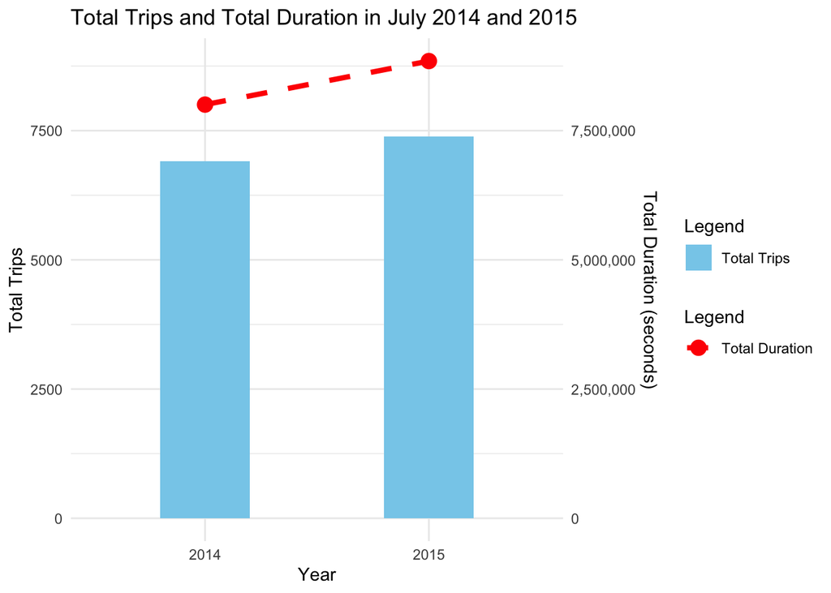

```r
data = data.frame(
  Year = c("2014", "2015"),
  Total_Trips = c(nrow(trips_2014), nrow(trips_2015)),
  Total_Duration = c(sum(trips_2014$duration), sum(trips_2015$duration))
)

ggplot(data) +
  geom_bar(aes(x = Year, y = Total_Trips, fill = "Total Trips"),
           stat = "identity", position = "dodge", width = 0.4) +
  geom_line(aes(x = Year, y = Total_Duration / 1000, group = 1, color = "Total Duration"),
            linewidth = 1.5, linetype = "dashed") +
  geom_point(aes(x = Year, y = Total_Duration / 1000, color = "Total Duration"),
             size = 4) +
  labs(title = "Total Trips and Total Duration in July 2014 and 2015",
       x = "Year", y = "Value",
       fill = "Legend", color = "Legend") +
  scale_y_continuous(
    name = "Total Trips",
    sec.axis = sec_axis(~ . * 1000, name = "Total Duration (seconds)",
                        labels = scales::comma)
  ) +
  scale_fill_manual(values = c("Total Trips" = "skyblue")) +
  scale_color_manual(values = c("Total Duration" = "red")) +
  theme_minimal()
```

#### Bar Chart for Average trip duration:

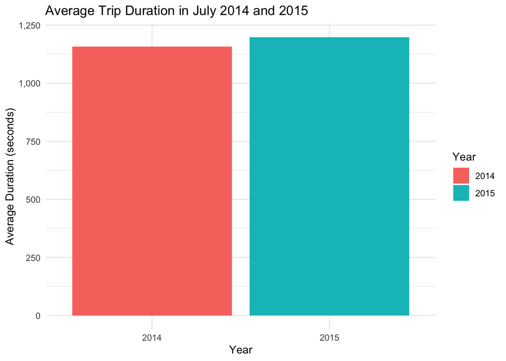

```r
avg_data = data.frame(
  Year = c("2014", "2015"),
  Average_Duration = c(mean(trips_2014$duration), mean(trips_2015$duration))
)

ggplot(avg_data, aes(x = Year, y = Average_Duration, fill = Year)) +
  geom_bar(stat = "identity") +
  labs(title = "Average Trip Duration in July 2014 and 2015",
       x = "Year", y = "Average Duration (seconds)") +
  theme_minimal() +
  scale_y_continuous(labels = scales::comma)
```

## c. Routes Statistics

We will first make a data frame contains start_station, end_station, num_trips, duration and avg_duration for both year:

```r
popular_routes_num_trips_2014 = aggregate(
  duration ~ start_station_name + end_station_name,
  data = trips_2014,
  FUN = length
)
colnames(popular_routes_num_trips_2014)[3] = "num_trips_2014"

popular_routes_duration_2014 = aggregate(
  duration ~ start_station_name + end_station_name,
  data = trips_2014,
  FUN = sum
)
colnames(popular_routes_duration_2014)[3] = "duration_2014"

popular_routes_2014 = merge(
  popular_routes_num_trips_2014,
  popular_routes_duration_2014,
  by = c("start_station_name", "end_station_name")
)

popular_routes_2014$avg_duration_2014 = round(popular_routes_2014$duration_2014 / popular_routes_2014$num_trips_2014, 2)


popular_routes_num_trips_2015 = aggregate(
  duration ~ start_station_name + end_station_name,
  data = trips_2015,
  FUN = length
)
colnames(popular_routes_num_trips_2015)[3] = "num_trips_2015"

popular_routes_duration_2015 = aggregate(
  duration ~ start_station_name + end_station_name,
  data = trips_2015,
  FUN = sum
)
colnames(popular_routes_duration_2015)[3] = "duration_2015"

popular_routes_2015 = merge(
  popular_routes_num_trips_2015,
  popular_routes_duration_2015,
  by = c("start_station_name", "end_station_name")
)

popular_routes_2015$avg_duration_2015 = round(popular_routes_2015$duration_2015 / popular_routes_2015$num_trips_2015, 2)
```

#### Top 5 popular routes (by number of trips):

- In July 2014:

```r
head(popular_routes_2014[order(-popular_routes_2014$num_trips_2014), ], 5)
```

```
##                           start_station_name       end_station_name
## 472     Harry Bridges Plaza (Ferry Building) Embarcadero at Sansome
## 383                   Embarcadero at Sansome      Steuart at Market
## 819 San Francisco Caltrain (Townsend at 4th)  Embarcadero at Folsom
## 43                         2nd at South Park      Market at Sansome
## 595                        Market at Sansome      2nd at South Park
##     num_trips_2014 duration_2014 avg_duration_2014
## 472             82        107834           1315.05
## 383             50         20609            412.18
## 819             48         39512            823.17
## 43              46         18234            396.39
## 595             46         17118            372.13
```

- In July 2015:

```r
head(popular_routes_2015[order(-popular_routes_2015$num_trips_2015), ], 5)
```

```
##                        start_station_name
## 466  Harry Bridges Plaza (Ferry Building)
## 1109                      Townsend at 7th
## 68                        2nd at Townsend
## 376                Embarcadero at Sansome
## 458  Harry Bridges Plaza (Ferry Building)
##                             end_station_name num_trips_2015 duration_2015
## 466                   Embarcadero at Sansome             86        302489
## 1109 San Francisco Caltrain 2 (330 Townsend)             79         72478
## 68      Harry Bridges Plaza (Ferry Building)             78         61099
## 376                        Steuart at Market             70         28426
## 458                          2nd at Townsend             58         38755
##      avg_duration_2015
## 466            3517.31
## 1109            917.44
## 68              783.32
## 376             406.09
## 458             668.19
```

#### Top 5 routes with longest duration:

- In July 2014:

```r
head(popular_routes_2014[order(-popular_routes_2014$duration_2014), ],5)
```

```
##                        start_station_name                      end_station_name
## 114              Arena Green / SAP Center                      Adobe on Almaden
## 796          San Antonio Caltrain Station      Castro Street and El Camino Real
## 784 Rengstorff Avenue / California Street Rengstorff Avenue / California Street
## 476  Harry Bridges Plaza (Ferry Building)  Harry Bridges Plaza (Ferry Building)
## 892                    San Jose City Hall                           Ryland Park
##     num_trips_2014 duration_2014 avg_duration_2014
## 114              1        715339         715339.00
## 796              2        145090          72545.00
## 784              2        119454          59727.00
## 476             16        113310           7081.88
## 892              2        111430          55715.00
```

- In July 2015:

```r
head(popular_routes_2015[order(-popular_routes_2015$duration_2015), ], 5)
```

```
##                        start_station_name               end_station_name
## 1121               University and Emerson         University and Emerson
## 466  Harry Bridges Plaza (Ferry Building)         Embarcadero at Sansome
## 670               Mountain View City Hall Mountain View Caltrain Station
## 578                         Market at 4th                  Market at 4th
## 391                Embarcadero at Vallejo                  Market at 4th
##      num_trips_2015 duration_2015 avg_duration_2015
## 1121             10       1205549         120554.90
## 466              86        302489           3517.31
## 670              34        167330           4921.47
## 578              14        145523          10394.50
## 391               5        132222          26444.40
```

#### Top 5 routes with longest average duration:

- In July 2014:

```r
head(popular_routes_2014[order(-popular_routes_2014$avg_duration_2014), ],5)
```

```
##                        start_station_name                      end_station_name
## 114              Arena Green / SAP Center                      Adobe on Almaden
## 796          San Antonio Caltrain Station      Castro Street and El Camino Real
## 784 Rengstorff Avenue / California Street Rengstorff Avenue / California Street
## 892                    San Jose City Hall                           Ryland Park
## 118              Arena Green / SAP Center     San Jose Diridon Caltrain Station
##     num_trips_2014 duration_2014 avg_duration_2014
## 114              1        715339            715339
## 796              2        145090             72545
## 784              2        119454             59727
## 892              2        111430             55715
## 118              2        108624             54312
```

- In July 2015:

```r
head(popular_routes_2015[order(-popular_routes_2015$avg_duration_2015), ], 5)
```

```
##                 start_station_name               end_station_name
## 1121        University and Emerson         University and Emerson
## 127       Arena Green / SAP Center            San Salvador at 1st
## 784  Redwood City Caltrain Station  Redwood City Caltrain Station
## 391         Embarcadero at Vallejo                  Market at 4th
## 1119        University and Emerson Mountain View Caltrain Station
##      num_trips_2015 duration_2015 avg_duration_2015
## 1121             10       1205549          120554.9
## 127               1         95920           95920.0
## 784               1         31381           31381.0
## 391               5        132222           26444.4
## 1119              2         46119           23059.5
```

**Insights**

```
1. Most Popular Routes

- Harry Bridges Plaza (Ferry Building) to Embarcadero at Sansome was the most frequent route in both years (82 trips in 2014, 86 in 2015), solidifying its role as a central commuter hub.
- 2015 saw new popular routes like Townsend at 7th to San Francisco Caltrain 2, reflecting changing commuter patterns.

2. Routes with Longest Total Durations

- 2014: Outlier trips like Arena Green / SAP Center to Adobe on Almaden (715,339 seconds) dominated.
- 2015: University and Emerson to itself emerged as the longest total duration route (1,205,549 seconds), indicating increased recreational use.

3. Routes with Longest Average Durations

- Both years featured outliers (e.g., University and Emerson, Arena Green / SAP Center) with unusually long durations, likely non-commuter trips.
```

### Plotting

#### Bar Chart for Most Popular Routes

First, I will combine data for both years for comparison

```r
popular_routes_combined = merge(
  popular_routes_2014[, c("start_station_name", "end_station_name", "num_trips_2014")],
  popular_routes_2015[, c("start_station_name", "end_station_name", "num_trips_2015")],
  by = c("start_station_name", "end_station_name"),
  all = TRUE
)
popular_routes_combined = popular_routes_combined[order(-popular_routes_combined$num_trips_2014, -popular_routes_combined$num_trips_2015), ]
```

Then, I only take the top 5 popular routes:

```r
popular_routes_top5 = head(popular_routes_combined, 5)

popular_routes_top5_long = data.frame(
  route = paste(popular_routes_top5$start_station_name, "->", popular_routes_top5$end_station_name),
  num_trips = c(popular_routes_top5$num_trips_2014, popular_routes_top5$num_trips_2015),
  year = rep(c("2014", "2015"), each = 5)
)

popular_routes_top5_long$route = paste(
  substr(popular_routes_top5$start_station_name, 1, 10),
  "...",
  "->",
  substr(popular_routes_top5$end_station_name, 1, 10),
  "..."
)
```

And plotting

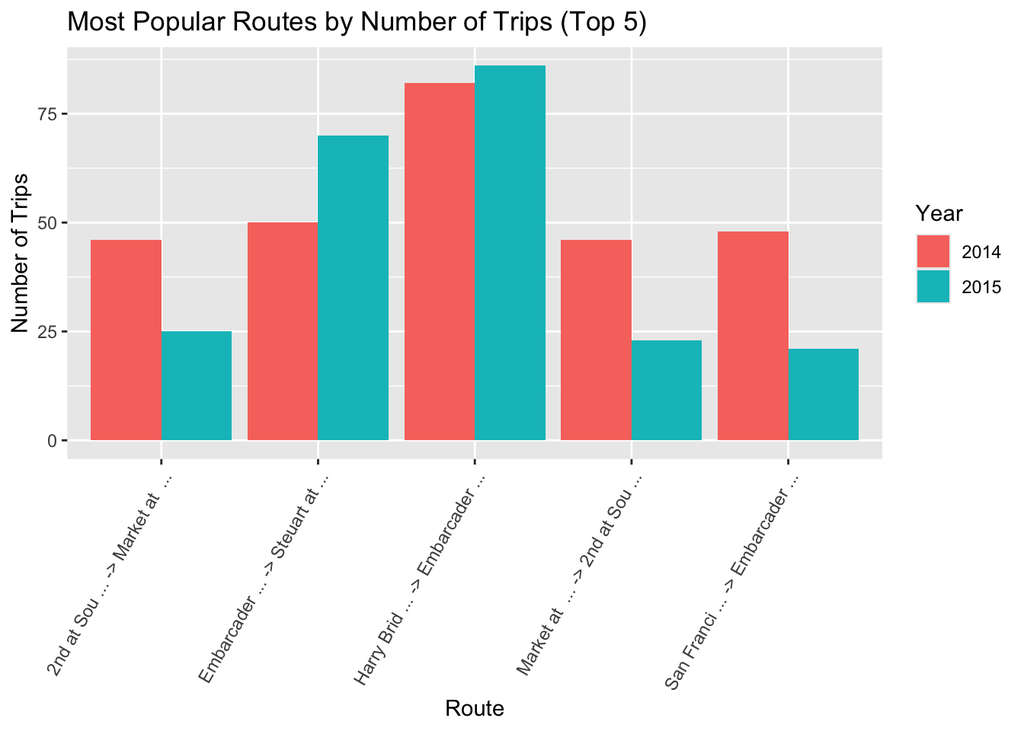

```r
ggplot(popular_routes_top5_long, aes(x = route, y = num_trips, fill = year)) +
  geom_bar(stat = "identity", position = "dodge") +
  labs(
    title = "Most Popular Routes by Number of Trips (Top 5)",
    x = "Route",
    y = "Number of Trips",
    fill = "Year"
  ) +
  theme(axis.text.x = element_text(angle = 60, hjust = 1))
```

First, I combine data for both years

```r
heatmap_data_2014 <- trips_2014[, c("start_station_name", "end_station_name")]
heatmap_data_2015 <- trips_2015[, c("start_station_name", "end_station_name")]
heatmap_data <- rbind(heatmap_data_2014, heatmap_data_2015)
```

And create heatmap data frame of top 25

```r
heatmap_df <- as.data.frame(table(heatmap_data$start_station_name, heatmap_data$end_station_name))
colnames(heatmap_df) <- c("Start_Station", "End_Station", "Frequency")
heatmap_df = head(heatmap_df[order(-heatmap_df$Frequency), ], 25)
```

And plotting:

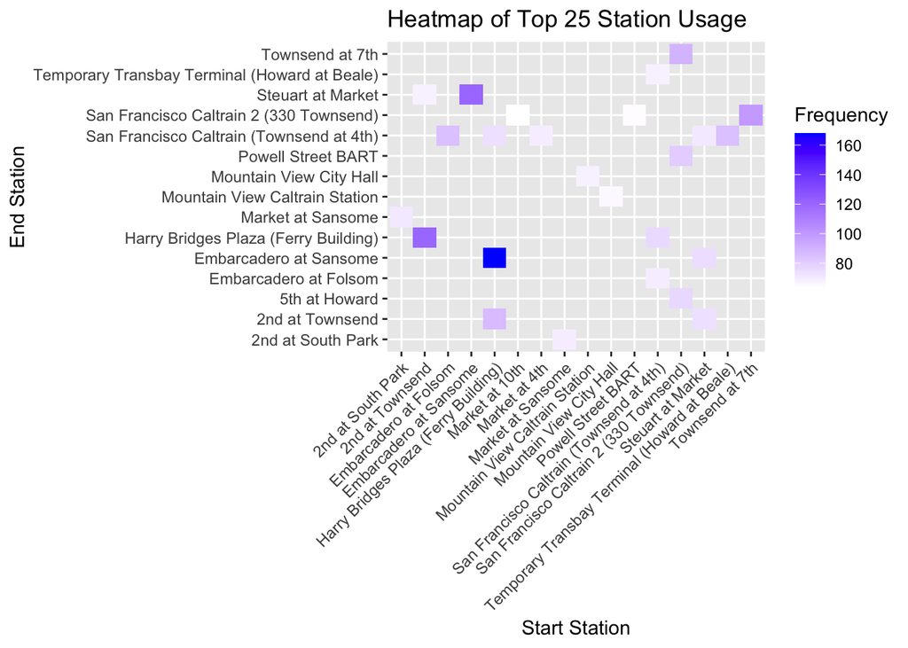

```r
ggplot(heatmap_df, aes(x = Start_Station, y = End_Station, fill = Frequency)) +
  geom_tile() +
  scale_fill_gradient(low = "white", high = "blue") +
  labs(
    title = "Heatmap of Top 25 Station Usage",
    x = "Start Station",
    y = "End Station",
    fill = "Frequency"
  ) +
  theme(axis.text.x = element_text(angle = 45, hjust = 1))
```

# Insights

- **Station Statistics:** The number of stations slightly increased from 69 in 2014 to 70 in 2015, with the addition of the Redwood City Medical Center station. San Francisco remains the central hub with the highest number of stations, while Palo Alto continues to have the fewest.
- **Trip Volumes:** Overall, trip volume and total duration grew from 6,911 trips (2,223.13 hours) in 2014 to 7,381 trips (2,457.26 hours) in 2015, reflecting greater bike-share usage. Average trip duration slightly increased, indicating longer rides over time.
- **Routes Statistics:** The most popular route was consistently between Harry Bridges Plaza and Embarcadero at Sansome, which remained the most traveled in both years. Routes with the longest durations were dominated by outliers, such as the Arena Green to Adobe on Almaden route in 2014 and University and Emerson in 2015, suggesting increased recreational or non-commuter use.

Overall, the data reflects growing bike-share usage, particularly in San Francisco, and a trend toward longer and more varied trips.